# Classification: Imbalanced Class

### Rebalance: Seismic Data

### Classification: SVM - Support Vector Machine

In my previous [R-notebook](https://github.com/arvindbetrabet/Classification_Imbalanced_Class_R/blob/master/RPART/Classification_Imbalanced_Class_RPART.Rmd) I delt with RPART classifier, post re-balancing of imbalance Seismic Data.

Here I am using SVM classifier, following the same process (reading, re-sampling and then classifying) so that each R-Notebooks can be used independently.

The Seismic data, recorded at a Polish coal mine is imbalanced, characterized by unbalanced distribution of positive and negative examples. In the data set there are only 170 positive examples representing class 1.[^1]

```r
library(foreign)
library(mlr)
library(ROSE)
library(FSelector)
set.seed(4567)
```

### Read the Data

```r
seismicData <- read.arff("data/seismic-bumps.arff")
summary(seismicData)
```

```
 seismic  seismoacoustic shift       genergy            gpuls           gdenergy
 a:1682   a:1580         N: 921   Min.   :    100   Min.   :   2.0   Min.   : -96.00
 b: 902   b: 956         W:1663   1st Qu.:  11660   1st Qu.: 190.0   1st Qu.: -37.00
          c:  48                  Median :  25485   Median : 379.0   Median :  -6.00
                                  Mean   :  90242   Mean   : 538.6   Mean   :  12.38
                                  3rd Qu.:  52832   3rd Qu.: 669.0   3rd Qu.:  38.00
                                  Max.   :2595650   Max.   :4518.0   Max.   :1245.00
     gdpuls        ghazard      nbumps          nbumps2          nbumps3
 Min.   :-96.000   a:2342   Min.   :0.0000   Min.   :0.0000   Min.   :0.0000
 1st Qu.:-36.000   b: 212   1st Qu.:0.0000   1st Qu.:0.0000   1st Qu.:0.0000
 Median : -6.000   c:  30   Median :0.0000   Median :0.0000   Median :0.0000
 Mean   :  4.509            Mean   :0.8595   Mean   :0.3936   Mean   :0.3928
 3rd Qu.: 30.250            3rd Qu.:1.0000   3rd Qu.:1.0000   3rd Qu.:1.0000
 Max.   :838.000            Max.   :9.0000   Max.   :8.0000   Max.   :7.0000
    nbumps4           nbumps5            nbumps6     nbumps7     nbumps89     energy
 Min.   :0.00000   Min.   :0.000000   Min.   :0   Min.   :0   Min.   :0   Min.   :     0
 1st Qu.:0.00000   1st Qu.:0.000000   1st Qu.:0   1st Qu.:0   1st Qu.:0   1st Qu.:     0
 Median :0.00000   Median :0.000000   Median :0   Median :0   Median :0   Median :     0
 Mean   :0.06772   Mean   :0.004644   Mean   :0   Mean   :0   Mean   :0   Mean   :  4975
 3rd Qu.:0.00000   3rd Qu.:0.000000   3rd Qu.:0   3rd Qu.:0   3rd Qu.:0   3rd Qu.:  2600
 Max.   :3.00000   Max.   :1.000000   Max.   :0   Max.   :0   Max.   :0   Max.   :402000
   maxenergy      class
 Min.   :     0   0:2414
 1st Qu.:     0   1: 170
 Median :     0
 Mean   :  4279
 3rd Qu.:  2000
 Max.   :400000
```

```r
summary(seismicData$class)
```

```
   0    1
2414  170
```

```r
# Remove the predictor variables that are constant
# or have zero variance
seismicData <- removeConstantFeatures(seismicData)
```

```
Removing 3 columns: nbumps6,nbumps7,nbumps89
```

```r
# Check the target variable class distribution
prop.table(table(seismicData$class))
```

```
         0          1
0.93421053 0.06578947
```

```r
# As percentage
table(seismicData$class)/nrow(seismicData)*100
```

```
        0         1
93.421053  6.578947
```

More than 93% of the target variable (class) is negative (0) or “non-hazardous”, which it should be, since the “shift” predictor variable (column 3) shows more mining activity (W - coal getting) than the provisioning activity (N - preparation). Provisioning activity, would include blasting, moving heavy machinery, etc..

But,

> Unbalanced distribution of positive (‘hazardous state’) and negative (‘non-hazardous state’) examples is a serious problem in seismic hazard prediction.  
> In the data set each row contains a summary statement about seismic activity in the rock mass within one shift (8 hours). If decision attribute has the value 1, then in the next shift any seismic bump with an energy higher than $10^4$ J was registered.

Thus, the main intent of this exercise is to re-balance the Seismic data. Evaluate the classification (the target class is a categorical variable) and document the improvement in predicting if an increase in seismic activity can result in a rock burst.

### Rebalancing

I am going to use the [mlr](http://mlr-org.github.io/mlr-tutorial/release/html/index.html) and [ROSE](https://cran.r-project.org/web/packages/ROSE/index.html) CRAN libraries. I would have preferred to use just one library, **mlr**, but unfortunately the logic of combined over-under sampling is yet to be implements (as of current release v2.9). ROSE has this composite over-under sampling method, which I am going to apply here.

The steps I am going to follow are:

- Oversample, Undersample, Balancesample and SMOTEsample the training subset
- Apply SVM classifier to the respective subsets, for this blog post
- RPART classifier appeared in a [previous](https://github.com/arvindbetrabet/Classification_Imbalanced_Class_R/blob/master/RPART/Classification_Imbalanced_Class_RPART.Rmd) post
- Naive Bayes classifier appeared in a [previous](https://github.com/arvindbetrabet/Classification_Imbalanced_Class_R/blob/master/RPART/Classification_Imbalanced_Class_NB2.Rmd) post
- Determine which of the 3 classifiers provide better results, as a concluding blog post, for this series

Split the Seismic Data into training and testing set

```r
sample_index <- sample(2,
                       nrow(seismicData),
                       replace = T,
                       prob = c(0.75,0.25))
#
#
seismicData_train <- seismicData[sample_index ==1 ,]
#
#
seismicData_test <- seismicData[sample_index == 2,]
```

Check the distribution of the target variable class, in the training set

```r
# As numbers
table(seismicData_train$class)
```

```
   0    1
1853  127
```

```r
# As percentage
table(seismicData_train$class)/nrow(seismicData_train)*100
```

```
        0         1
93.585859  6.414141
```

The test set has the following distribution.

```r
# As numbers
table(seismicData_test$class)
```

```
  0   1
561  43
```

```r
# As percentage
table(seismicData_test$class)/nrow(seismicData_test)*100
```

```
        0         1
92.880795  7.119205
```

Notice the training and test sets, have nearly the same distribution of the predictor variable, class.

The first step when using the mlr package, is to define a task and perform the sampling on the training set. To overcome the lack of balanced sampling, I used the ROSE package.

Reference[^2] has a visual explanation to aid the concept of over and under sampling.

In principle, over-sampling is where the minority class (positive/1 in this dataset) is randomly sampled and its number is augmented to bring it on-par with the majority class (negative/0 in this dataset). Under-sampling on the other hand, randomly selects data from the majority class and discards them, so that both the classes even out, as seen in the next section. Balanced sampling is a combination of both, under and over sampling.

After some trial-and-error, the rate setting for the over and under sampling was chosen so as to have the negative and positive class numbers as close as possible (as seen by the distribution)

```r
#Define the basic classification task
task_train <- makeClassifTask(data = seismicData_train, target = "class")
#Over sampling task
task_train_over <- oversample(task_train, rate = 13.4)
#Under sampling task
task_train_under <- undersample(task_train, rate = 1/13.4)
#Balanced sampling using the ROSE package, combination of over and under sampling
seismicData_train_balanced <- ovun.sample(class ~ ., data = seismicData_train, method = "both", p = 0.5)$data
#Balanced sampling task
task_train_balanced <- makeClassifTask(data = seismicData_train_balanced, target = "class")
#SMOTE(Synthetic Minority Oversampling Technique)
task_train_smote <- smote(task_train, rate = 13.4, nn = 10)
```

```
binary variable(s) 13 treated as interval scaled
```

Distribution of training set, unbalanced.

```r
# As numbers
table(getTaskTargets(task_train))
```

```
   0    1
1853  127
```

```r
# As percentage
table(getTaskTargets(task_train))/nrow(seismicData_train)*100
```

```
        0         1
93.585859  6.414141
```

Distribution of training set, over-sampled.

```r
# As numbers
table(getTaskTargets(task_train_over))
```

```
   0    1
1853 1702
```

```r
# As percentage
table(getTaskTargets(task_train_over))/nrow(seismicData_train)*100
```

```
       0        1
93.58586 85.95960
```

Distribution of training set, under-sampled.

```r
# As numbers
table(getTaskTargets(task_train_under))
```

```
  0   1
138 127
```

```r
# As percentage
table(getTaskTargets(task_train_under))/nrow(seismicData_train)*100
```

```
       0        1
6.969697 6.414141
```

Distribution of training set, balance-sampled.

```r
table(getTaskTargets(task_train_balanced))
```

```
  0   1
991 989
```

```r
table(getTaskTargets(task_train_balanced))/nrow(seismicData_train)*100
```

```
       0        1
50.05051 49.94949
```

Distribution of training set, SMOTE-sampled.

```r
table(getTaskTargets(task_train_smote))
```

```
   0    1
1853 1702
```

```r
table(getTaskTargets(task_train_smote))/nrow(seismicData_train)*100
```

```
       0        1
93.58586 85.95960
```

### SVM

This section covers a brief overview of the SVM classifier, which is well documented in textbooks, journals and papers, and is included here to present a cogent view.

Support Vector Machine (SVM), was conceptualized by Vladimir Vapnik, in the late 1970 - early 1980s as a way of classifying data. In 1995, along with a co-author [^3] Vapnik, introduced a more general Support-Vector Network as a new learning machine, as applied to Optical Character Recognition.

SVM is a supervised machine learning algorithm which can be used for classification or regression exercise, using a technique termed as the kernel trick to transform data. Based on these transformations, the SVM finds an optimal boundary between the possible outcomes, essentially it figures out how to separate the data, based on the outcome labels. See the figure below:

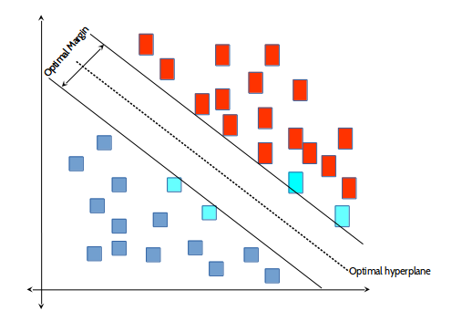

Fig1. - An example of a separable problem in a 2-D space. The support vectors, colored cyan, define the margin of largest, clean separation between the two classes.

Another [site](http://www.svm-tutorial.com/) provided historical and mathematical background on SVM, that helped me better understand the Support Vector Machine. A python based explanation about SVM is [here](http://blog.yhat.com/posts/why-support-vector-machine.html)

Next steps are to, define a SVM learner, train it on the sampled training set and perform the classification on the testing set.

```r
learner_svm <- makeLearner("classif.svm", predict.type = "prob")
```

Train on the imbalanced training data.

```r
model_svm_train <- train(learner_svm, task_train)
```

Train on the balance-sampled training data.

```r
model_svm_train_balanced <- train(learner_svm, task_train_balanced) #balanced sampling
```

Train on the over-sampled training data.

```r
model_svm_train_over <- train(learner_svm, task_train_over) #over sampling
```

Train on the under-sampled training data.

```r
model_svm_train_under <- train(learner_svm, task_train_under) #under sampling
```

Train on the SMOTE-sampled training data.

```r
model_svm_train_smote <- train(learner_svm, task_train_smote) #SMOTE sampling
```

Now, using the test set, perform the classification prediction and evaluate the performance. There a variety of performance measures [^4], but I have chosen the following:

- mmce - Mean mis-classification error
- ber - Balanced error rate
- auc - Area under the curve

```r
# Performance of the model using the un-balanced training set.
performance(predict(model_svm_train, newdata = seismicData_test), measures = list(mmce, ber, auc))
```

```
      mmce        ber        auc
0.07119205 0.50000000 0.57173652
```

```r
# Performance of the model using the balanced-sampling balanced training set.
performance(predict(model_svm_train_balanced, newdata = seismicData_test), measures = list(mmce, ber, auc))
```

```
     mmce       ber       auc
0.2516556 0.3179953 0.7207644
```

```r
# Performance of the model using the over-sampling balanced training set.
performance(predict(model_svm_train_over, newdata = seismicData_test), measures = list(mmce, ber, auc))
```

```
     mmce       ber       auc
0.2400662 0.3224931 0.7241844
```

```r
# Performance of the model using the under-sampling balanced training set.
performance(predict(model_svm_train_under, newdata = seismicData_test), measures = list(mmce, ber, auc))
```

```
     mmce       ber       auc
0.2185430 0.2572234 0.7610165
```

```r
# Performance of the model using the SMOTE-sampling balanced training set.
performance(predict(model_svm_train_smote, newdata = seismicData_test), measures = list(mmce, ber, auc))
```

```
     mmce       ber       auc
0.2864238 0.3581851 0.7198110
```

Even though, the performance of the model using un-balanced dataset, has low mmce (0.07) and modest auc (0.57), it certainly hides the imbalance of the predictor class.

The performance results indicate that the model using under-sampling of the imbalanced dataset does better than the others, in light of the following from the developers of the mlr package.

> Performance measure has to be considered very carefully.  
> As the misclassification rate (mmce) evaluates the overall accuracy of the predictions, the balanced error rate (ber) and area under the ROC Curve (auc) might be more suitable here, as the misclassifications within each class are separately taken into account.

### *References*

[^1]: UCI Machine Learning Repository (https://archive.ics.uci.edu/ml/datasets/seismic-bumps)
[^2]: Learning from Imbalanced Classes (https://svds.com/learning-imbalanced-classes/)
[^3]: Cortes, C. & Vapnik, V. Machine Learning (1995) 20: 273. doi:10.1023/A:1022627411411
[^4]: Implemented Performance Measures, Machine Learning in R. (http://mlr-org.github.io/mlr-tutorial/release/html/measures/index.html)